# Cálculo del área oscura

## Idea

Para extraer informacion de separacion de platos se observo que al abrir los platos, se genera un area oscura en las caras internas de los mismos, producto de la poca luz que entra por la forma de campana que estos tienen y del reflejo de la luz con las camperas de color oscuro.

Se analizo en un principio utilizar la deteccion de manos para definir que zona especifica observar para buscar el area oscura, sin embargo debido al posicionamiento de las camaras y al movimiento de los musicos (dificultad prevista previamente), no es posible posicionar correctamente las manos.

Luego de descartada esta posibilidad, se observo que mas haya de la variacion del area oscura, el resto de los colores oscuros presentes en la imagen se mantienen presentes a lo largo del video, o tienen una variacion mucho mas lenta que proviene del movimiento del musico. Con esta consideracion, se procedio a enmascarar los colores oscuros y calcular el area de esta mascara.

## Refinado de parametros

Los resultados de el area hallada se filtraron pasabajos mediante una media movil para quitar los picos generados por la baja calidad de la imagen y otros ruidos no deseados. Y luego se filtro pasa altos, para eliminar la variacion lenta del color total, proviniente del movimiento de los musicos.

Se grafico el valor calculado sobre la pista de audio que mostraba picos de amplitud en los mismos intantes que los minimos del area, como era esperado. Tambien se hallo los picos minimos y se graficaron estos puntos temporales sobre la señal de audio para optimizar los parametros disponibles (ancho de la media movil, frecuencia de corte del filtro pasa altos, ancho y prominencia de los picos calculados, etc.).

El ultimo paso de optimizacion de parametros consistio en la aplicacion de un "flash" sobre el video del musico en cada pico detectado. Con este ultimo metodo se observo que los resultados obtenidos captan un alto porcentaje de golpes, pero tambien detecta golpes en momentos donde no los hay. Sin embargo este analisis sumado a un estudio del audio puede complementarse de buena forma.

## Generalizacion

El siguiente paso consistio en aplicar el metodo de los flashes a distintos videos, sin analizar el audio, y se verifico que los parametros hallados son bastante generales.

## Etiquetado

Por ultimo se busco etiquetar los golpes en funcion de la informacion de la sombra, para esto se tuvo en cuenta dos factores:

- La cercania entre picos, ya que dos golpes muy seguidos no pueden ser muy abiertos y por lo tanto seran un tipo de golpe cerrado
- La presencia de un pico invertido (mucha sombra) grande entre dos golpes, lo cual corresponderia a un golpe abierto.

```python
import numpy as np
from matplotlib import pyplot as plt
from skimage.io import imread, imsave
from skimage import data, color, img_as_ubyte
from skimage.feature import canny
from skimage.transform import hough_ellipse
from skimage.draw import ellipse_perimeter
from scipy import signal
from scipy import misc
import scipy.ndimage.filters as filters
import scipy.ndimage as ndimage

import math
import time
import pdb
import os
import cv2
import skimage
#import imutils


# Esto cambia si las figuras quedan en línea en el notebook o se abren ventanas
# aparte.
%matplotlib inline
#%matplotlib

# Algunos parámetros para controlar en general el aspecto de las figuras
plt.rcParams['figure.figsize'] = (20, 5) # set default size of plots
plt.rcParams['image.cmap'] = 'gray' #colormap por defecto
```

## Primer acercamiento

```python
lower_dark1 = (0,40,0)
upper_dark1 = (360,255,50)
#lower_dark2 = (170,180,0)
#upper_dark2 = (180,255,130)
```

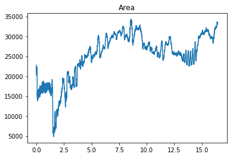

```python
#ENMASCARADO DE oscuridad
cap = cv2.VideoCapture('./gopro1/Rito/undistorted/platos/cropped/crop_undist_GOPR0571.MP4')
area=[]
while(cap.isOpened()):
    ret, frame = cap.read()
    if ret==False:
        break

    I_hsv = cv2.cvtColor(frame, cv2.COLOR_BGR2HSV)

    mask = cv2.inRange(I_hsv, lower_dark1, upper_dark1)
    #mask2 = cv2.inRange(I_hsv, lower_dark2, upper_dark2)

    ## Merge the mask and crop the red regions
    #mask = cv2.bitwise_or(mask1, mask2 )
    croped = cv2.bitwise_and(frame, frame, mask=mask)

    cv2.imshow('mask',mask)

    cv2.imshow('frame',frame)

    area.append(np.sum(mask == 255))


    if cv2.waitKey(1) & 0xFF == ord('q'):
        break

cap.release()
cv2.destroyAllWindows()

Time=np.linspace(0, len(area)/240, num=len(area))

#ploteo
plt.figure(1)
plt.plot(Time,area)
plt.title('Area')
```

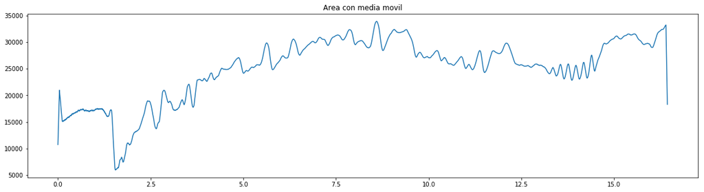

```python
Time=np.linspace(0, len(area)/240, num=len(area))

N=20
liso=np.convolve(area, np.ones((N,))/N, mode='same')
#ploteo
plt.figure(1)
plt.plot(Time,liso)
plt.title('Area con media movil')
```

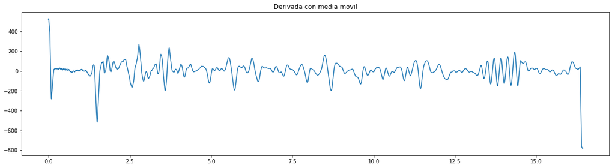

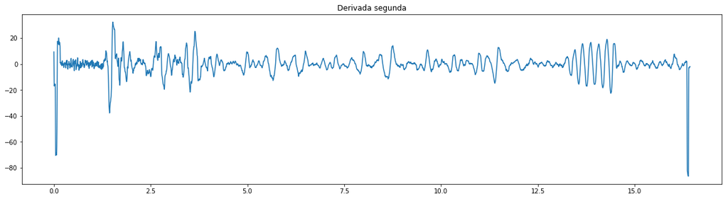

```python
deriv=np.gradient(liso)
derivliso=np.convolve(deriv, np.ones((N,))/N, mode='same')
#ploteo
plt.figure(2)
plt.plot(Time,derivliso)
plt.title('Derivada con media movil')

deriv2=np.gradient(derivliso)
#ploteo
plt.figure(3)
plt.plot(Time,deriv2)
plt.title('Derivada segunda')
```

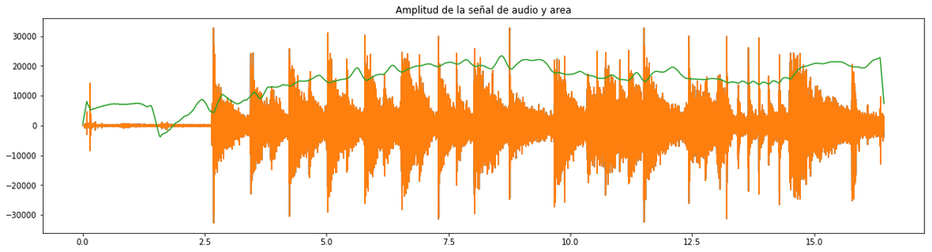

```python
from scipy.io import wavfile as wav
rate, data = wav.read('GOPR0571audio.wav')
Time=np.linspace(0, len(data)/rate, num=len(data))

plt.plot(Time,data)
plt.figure(1)

Time=np.linspace(0, len(area)/240, num=len(area))

N=40
liso=np.convolve(area, np.ones((N,))/N, mode='same')
#ploteo
plt.figure(1)
plt.plot(Time,liso-10000)
plt.title('Amplitud de la señal de audio y area')
```

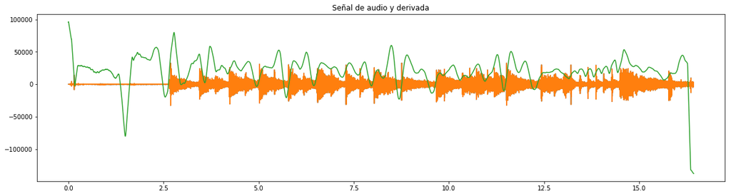

```python
Time=np.linspace(0, len(data)/rate, num=len(data))

plt.figure(3)
plt.plot(Time,data)
plt.figure(figsize=(20,20))


Time=np.linspace(0, len(liso)/240, num=len(liso))

deriv=np.gradient(liso)
derivliso=np.convolve(deriv, np.ones((N,))/N, mode='same')
#ploteo
plt.figure(3)
plt.plot(Time,400*derivliso+20000)
plt.title('Señal de audio y derivada')
```

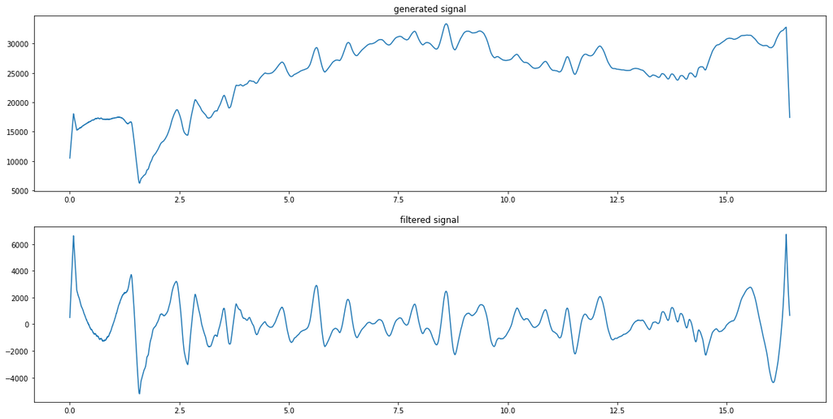

```python
import numpy as np
from scipy import signal
import matplotlib.pyplot as plt

def butter_highpass(cutoff, fs, order=5):
    nyq = 0.5 * fs
    normal_cutoff = cutoff / nyq
    b, a = signal.butter(order, normal_cutoff, btype='high', analog=False)
    return b, a

def butter_highpass_filter(data, cutoff, fs, order=5):
    b, a = butter_highpass(cutoff, fs, order=order)
    y = signal.filtfilt(b, a, data)
    return y



filtered = butter_highpass_filter(liso,.6,240)


Time=np.linspace(0, len(liso)/240, num=len(liso))

plt.figure(figsize=(20,10))
plt.subplot(211)
plt.plot(Time,liso)
plt.title('generated signal')
plt.subplot(212)
plt.plot(Time,filtered)
plt.title('filtered signal')
plt.show()
```

Ref: https://stackoverflow.com/a/39032946

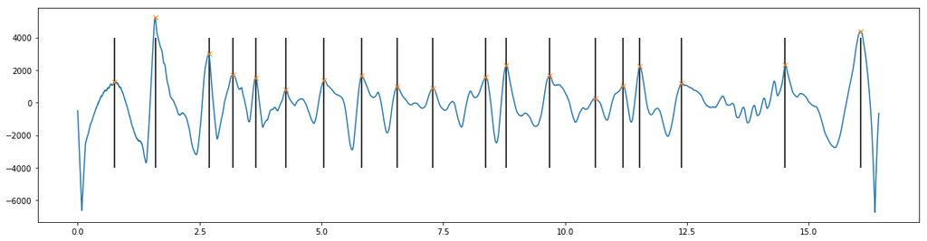

```python
from scipy.signal import find_peaks
filteredinv=-filtered
peaks, properties=find_peaks(filteredinv,prominence=900,width=15)
plt.plot(Time,filteredinv)
plt.plot(peaks/240,filteredinv[peaks],"x")
plt.vlines(x=peaks/240,ymin=-4000,ymax=4000)
plt.show()
```

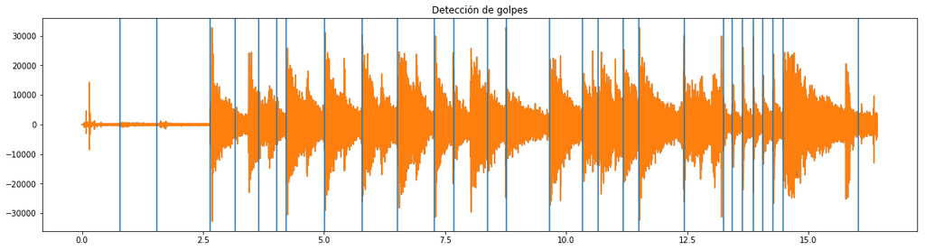

```python
from scipy.io import wavfile as wav
from scipy.signal import find_peaks

rate, data = wav.read('GOPR0571audio.wav')
Time=np.linspace(0, len(data)/rate, num=len(data))

plt.plot(Time,data)

filteredinv=-filtered
peaks, properties=find_peaks(filteredinv,prominence=800,width=15)
for x in peaks:
    plt.axvline(x/240)
plt.title("Detección de golpes")
plt.show()
```

```python
cap = cv2.VideoCapture('./gopro1/Rito/undistorted/platos/cropped/crop_undist_GOPR0571.MP4')
t=0
while(cap.isOpened()):
    ret, frame = cap.read()
    t+=1
    if ret==False:
        break

    if (t in peaks) or ((t-1) in peaks) or ((t-2) in peaks):
        frame=255*np.ones(frame.shape)

    cv2.imshow('frame',frame)


    if cv2.waitKey(1) & 0xFF == ord('q'):
        break

cap.release()
cv2.destroyAllWindows()
```

## Generalizacion

Observacion de si los parametros hayados escalaban correctamente a los otros videos de la base de datos

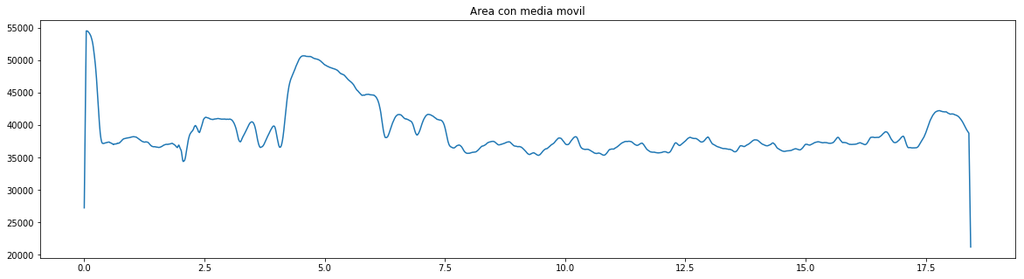

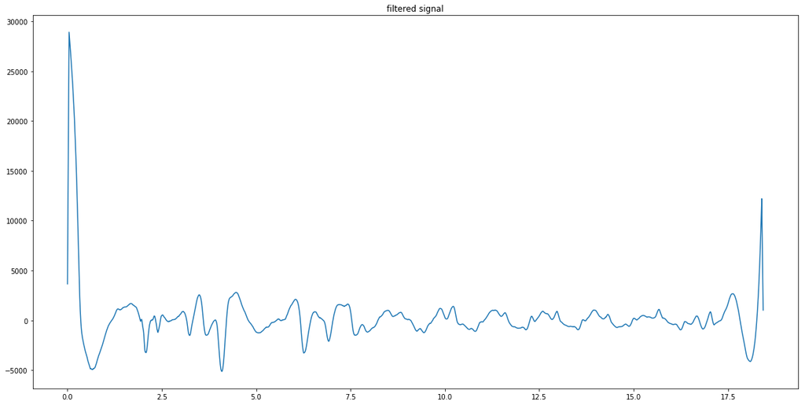

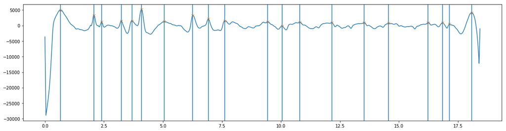

```python
import numpy as np
from scipy import signal
import matplotlib.pyplot as plt
from scipy.signal import find_peaks

def butter_highpass(cutoff, fs, order=5):
    nyq = 0.5 * fs
    normal_cutoff = cutoff / nyq
    b, a = signal.butter(order, normal_cutoff, btype='high', analog=False)
    return b, a

def butter_highpass_filter(data, cutoff, fs, order=5):
    b, a = butter_highpass(cutoff, fs, order=order)
    y = signal.filtfilt(b, a, data)
    return y


lower_dark1 = (0,40,0)
upper_dark1 = (360,255,50)
#ENMASCARADO DE oscuridad
video='./gopro1/Eva/undistorted/platos/cropped/crop_undist_GOPR0567.MP4'
cap = cv2.VideoCapture(video)
area=[]
while(cap.isOpened()):
    ret, frame = cap.read()
    if ret==False:
        break

    I_hsv = cv2.cvtColor(frame, cv2.COLOR_BGR2HSV)

    mask = cv2.inRange(I_hsv, lower_dark1, upper_dark1)

    croped = cv2.bitwise_and(frame, frame, mask=mask)

    area.append(np.sum(mask == 255))

cap.release()
cv2.destroyAllWindows()

Time=np.linspace(0, len(area)/240, num=len(area))

N=20
liso=np.convolve(area, np.ones((N,))/N, mode='same')
#ploteo
plt.figure(1)
plt.plot(Time,liso)
plt.title('Area con media movil')

filtered = butter_highpass_filter(liso,.6,240)

plt.figure(figsize=(20,10))
plt.plot(Time,filtered)
plt.title('filtered signal')
plt.show()

filteredinv=-filtered
peaks, properties=find_peaks(filteredinv,prominence=1000,width=15,distance=10)
plt.plot(Time,filteredinv)
plt.plot(peaks/240,filteredinv[peaks],"x")
for x in peaks:
    plt.axvline(x/240,label="test")
plt.show()

cap = cv2.VideoCapture(video)
vid_writer = cv2.VideoWriter('./platos/flash_'+os.path.basename(video),cv2.VideoWriter_fourcc('M','J','P','G'), 240, (mask.shape[1],mask.shape[0]))

t=0
while(cap.isOpened()):
    ret, frame = cap.read()
    t+=1
    if ret==False:
        break

    if (t in peaks) or ((t-1) in peaks) or ((t-2) in peaks):
        frame=np.uint8(255*np.ones(frame.shape))
        #frame=255-frame

    cv2.imshow('frame',frame)
    if frame.shape[0]*frame.shape[1] > 0:
            vid_writer.write(frame)
    if cv2.waitKey(1) & 0xFF == ord('q'):
        break

vid_writer.release()
cap.release()
cv2.destroyAllWindows()
```

## Etiquetado

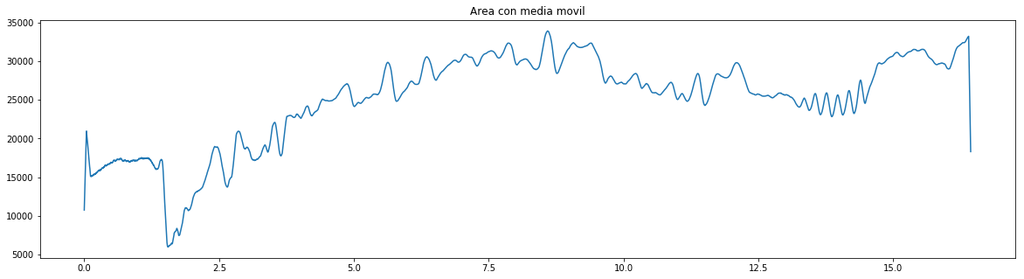

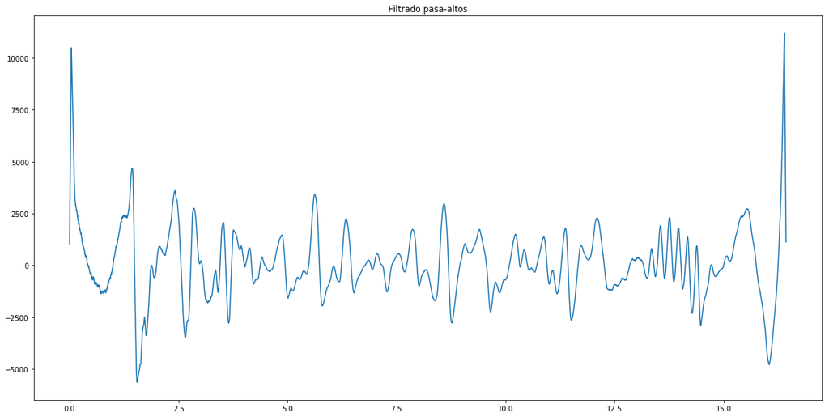

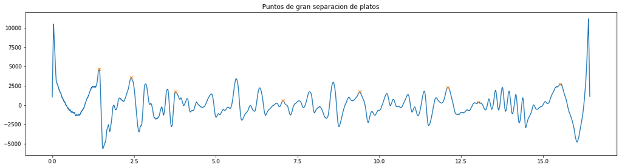

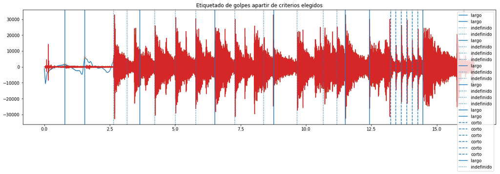

```python
import numpy as np
from scipy import signal
import matplotlib.pyplot as plt
from scipy.signal import find_peaks
from scipy.io import wavfile as wav

def butter_highpass(cutoff, fs, order=5):
    nyq = 0.5 * fs
    normal_cutoff = cutoff / nyq
    b, a = signal.butter(order, normal_cutoff, btype='high', analog=False)
    return b, a

def butter_highpass_filter(data, cutoff, fs, order=5):
    b, a = butter_highpass(cutoff, fs, order=order)
    y = signal.filtfilt(b, a, data)
    return y

def common_data(list1, list2):
    result = False

    # traverse in the 1st list
    for x in list1:

        # traverse in the 2nd list
        for y in list2:

            # if one common
            if x == y:
                result = True
                return result

    return result

lower_dark1 = (0,40,0)
upper_dark1 = (360,255,50)
#ENMASCARADO DE oscuridad
video='./gopro1/Rito/undistorted/platos/cropped/crop_undist_GOPR0571.MP4'
cap = cv2.VideoCapture(video)
area=[]
while(cap.isOpened()):
    ret, frame = cap.read()
    if ret==False:
        break

    I_hsv = cv2.cvtColor(frame, cv2.COLOR_BGR2HSV)

    mask = cv2.inRange(I_hsv, lower_dark1, upper_dark1)

    croped = cv2.bitwise_and(frame, frame, mask=mask)

    area.append(np.sum(mask == 255))

cap.release()
cv2.destroyAllWindows()

Time=np.linspace(0, len(area)/240, num=len(area))

N=20
liso=np.convolve(area, np.ones((N,))/N, mode='same')
#ploteo
plt.figure(1)
plt.plot(Time,liso)
plt.title('Area con media movil')

filtered = butter_highpass_filter(liso,.6,240)

plt.figure(figsize=(20,10))

plt.plot(Time,filtered)
plt.title('Filtrado pasa-altos')
plt.show()

peaksinv, properties=find_peaks(filtered,prominence=90,width=65,distance=40)
plt.plot(Time,filtered)
plt.plot(peaksinv/240,filtered[peaksinv],"x")
plt.title("Puntos de gran separacion de platos")
plt.show()

filteredinv=-filtered
peaks, properties=find_peaks(filteredinv,prominence=1000,width=15,distance=10)
plt.plot(Time,filteredinv)
plt.plot(peaks/240,filteredinv[peaks],"x")

rate, data = wav.read('GOPR0571audio.wav')
Time=np.linspace(0, len(data)/rate, num=len(data))
plt.plot(Time,data)


for x in peaks:
    aux1=np.where(peaks==x)[0]
    if aux1!=len(peaks)-1:
        aux2=peaks[aux1+1]
    else:
        aux2=len(filteredinv)
    r=np.arange(x,aux2)


    if common_data(r, peaksinv):
        plt.axvline(x/240,label="largo")
    elif (aux2-x)<60:
        plt.axvline(x/240,label="corto",linestyle='--')
    else:
        plt.axvline(x/240, label="indefinido",linestyle=':')
plt.legend()
plt.title("Etiquetado de golpes apartir de criterios elegidos")
plt.show()

cap = cv2.VideoCapture(video)
vid_writer = cv2.VideoWriter('./platos/flash_'+os.path.basename(video),cv2.VideoWriter_fourcc('M','J','P','G'), 240, (mask.shape[1],mask.shape[0]))

t=0
while(cap.isOpened()):
    ret, frame = cap.read()
    t+=1
    if ret==False:
        break

    if (t in peaks) or ((t-1) in peaks) or ((t-2) in peaks):
        frame=np.uint8(255*np.ones(frame.shape))
        #frame=255-frame

    cv2.imshow('frame',frame)
    if frame.shape[0]*frame.shape[1] > 0:
            vid_writer.write(frame)
    if cv2.waitKey(1) & 0xFF == ord('q'):
        break

vid_writer.release()
cap.release()
cv2.destroyAllWindows()
```